# RA_TP1

Fernando Coz

2023-06-01

## Inicio

```r
rm( list = ls(all.names = TRUE) )
gc( full = TRUE )
```

```
##          used (Mb) gc trigger (Mb) max used (Mb)
## Ncells 508875 27.2    1131805 60.5   644245 34.5
## Vcells 898192  6.9    8388608 64.0  1635652 12.5
```

## Librerias

```r
require(ggpmisc)
require(readxl)
require(MVN)
```

## Resolución

## Ejercicio 1.1

### Dataset

```r
g_cerdos <- read_excel("./datasets/grasacerdos.xlsx")
```

### a) Diagrama de dispersión

```r
#Calculo la media muestral de cada una de las variables
u_PV <- mean(g_cerdos$PV)
u_EGD <- mean(g_cerdos$EGD)
```

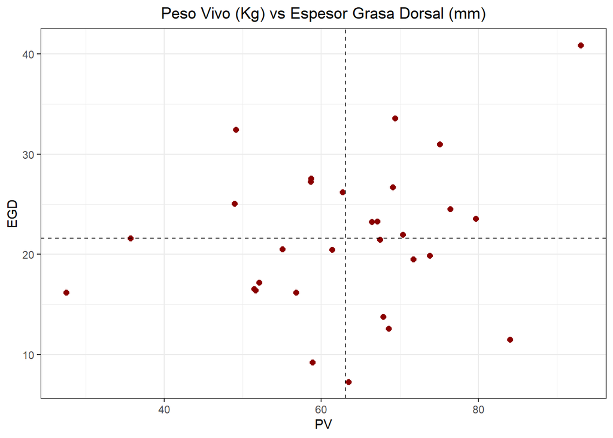

```r
ggplot( data = g_cerdos, aes( x = PV, y = EGD ) ) +
  geom_point( colour = "red4", size = 2) +
  ggtitle( "Peso Vivo (Kg) vs Espesor Grasa Dorsal (mm)" ) +
  theme_bw() +
  theme( plot.title = element_text( hjust = 0.5 ) ) +
  geom_vhlines( xintercept = u_PV, yintercept = u_EGD, linetype = "dashed")
```

```r
#Puedo también contabilizar la cantidad de puntos por cuadrante

x_sup <- g_cerdos$PV > u_PV
y_sup <- g_cerdos$EGD > u_EGD

# Step 3: Determine observations in each quadrant
q1 <- x_sup & y_sup
q2 <- !x_sup & y_sup
q3 <- !x_sup & !y_sup
q4 <- x_sup & !y_sup

# Step 4: Count observations in each quadrant
count_q1 <- sum(q1)
count_q2 <- sum(q2)
count_q3 <- sum(q3)
count_q4 <- sum(q4)

cat("Cuadrante 1:", count_q1, "\n")
```

```
## Cuadrante 1: 9
```

```r
cat("Cuadrante 2:", count_q2, "\n")
```

```
## Cuadrante 2: 6
```

```r
cat("Cuadrante 3:", count_q3, "\n")
```

```
## Cuadrante 3: 8
```

```r
cat("Cuadrante 4:", count_q4, "\n")
```

```
## Cuadrante 4: 7
```

No se oberva a simple vista un correlación lineal entre los puntos. Aunque parecería existir una correlación positiva ya que se observa mayor cantidad de puntos en los cuadrantes I y III.

### b) Coeficiente correlación muestral

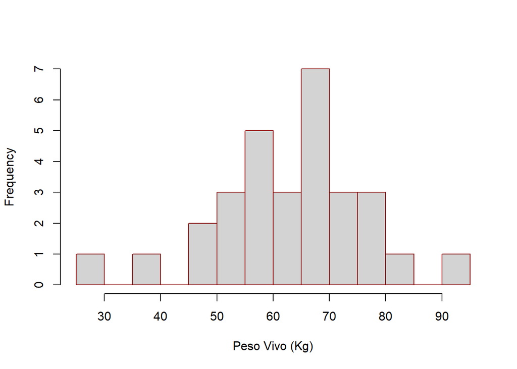

```r
#Analizamos normalidad de las variables

hist(g_cerdos$PV,
     breaks = 10,
     main = "",
     xlab = "Peso Vivo (Kg)",
     border = "darkred" )
```

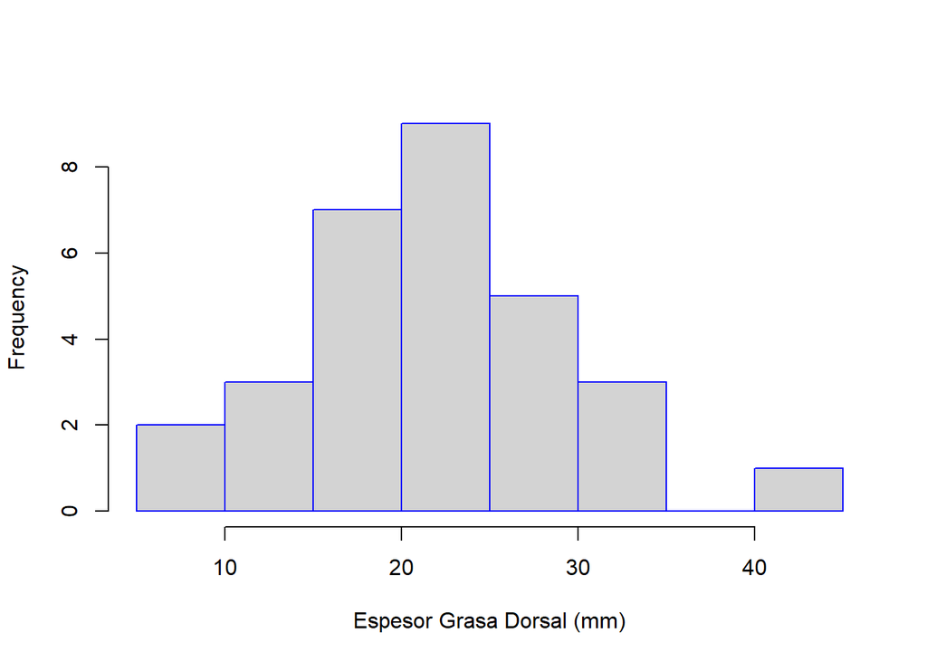

```r
hist(g_cerdos$EGD,
     breaks = 10,
     main = "",
     xlab = "Espesor Grasa Dorsal (mm)",
     border = "blue" )
```

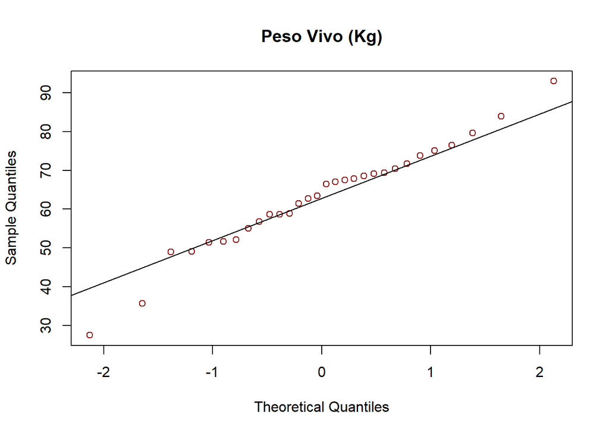

```r
qqnorm( g_cerdos$PV,
        main = "Peso Vivo (Kg)",
        col = "darkred" )
qqline( g_cerdos$PV )
```

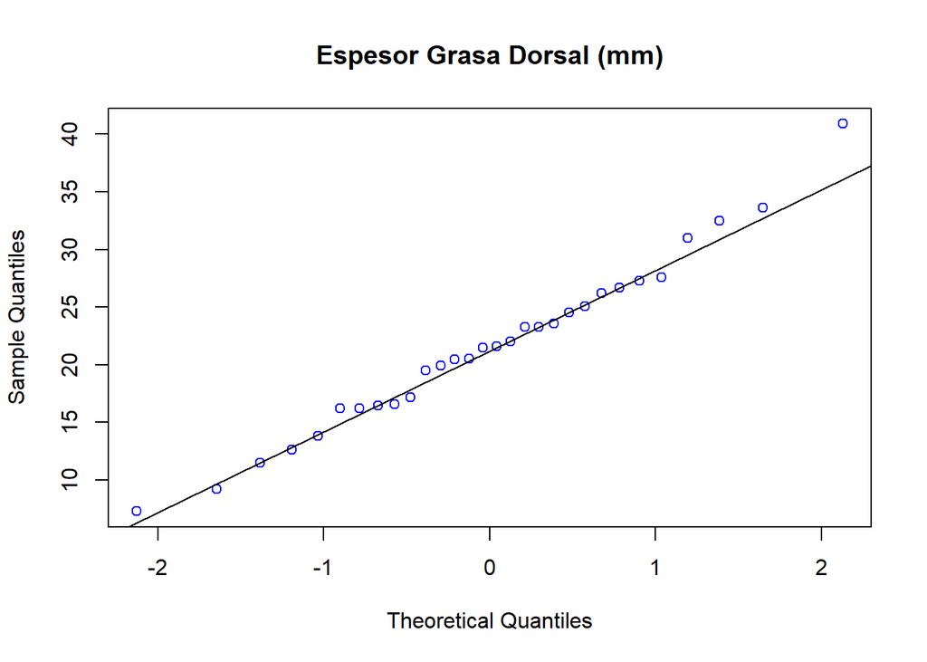

```r
qqnorm( g_cerdos$EGD,
        main = "Espesor Grasa Dorsal (mm)",
        col = "blue" )
qqline( g_cerdos$EGD )
```

Analizo que la distribución conjunta de las variables sea normal bivariada. Si no se cumple, la correlación debe estimarse en forma no paramétrica mediante el coeficiente de correlación de Spearman.

```r
result <- mvn(g_cerdos, mvnTest = "hz")
result$multivariateNormality
```

```
##            Test        HZ   p value MVN
## 1 Henze-Zirkler 0.6379234 0.3891766 YES
```

Puede entonces, sostenerse el supuesto distribucional normal bivariado para estas variables.

### c) Supuestos

Dado que se cumplen los supuestos de normalidad, entonces puedo usar el test de correlación de Pearson dado que se cumplen los supuestos de normalidad y linealidad.

```r
cor( g_cerdos$PV, g_cerdos$EGD )
```

```
## [1] 0.2543434
```

```r
cor( g_cerdos$PV, g_cerdos$EGD, method="pearson" )
```

```
## [1] 0.2543434
```

```r
cor.test( g_cerdos$PV, g_cerdos$EGD, method="pearson" )
```

```
##
##  Pearson's product-moment correlation
##
## data:  g_cerdos$PV and g_cerdos$EGD
## t = 1.3916, df = 28, p-value = 0.175
## alternative hypothesis: true correlation is not equal to 0
## 95 percent confidence interval:
##  -0.1166112  0.5630217
## sample estimates:
##       cor
## 0.2543434
```

No rechazas H0 porque el 0 está incluido (el rango va de -0.11 a 0.56). Por lo tanto no existe correlación entre las variables.

## Ejercicio 1.2

### Dataset

```r
anscombe <- read_excel("./datasets/anscombe.xlsx")
```

### a) Diagramas de dispresión

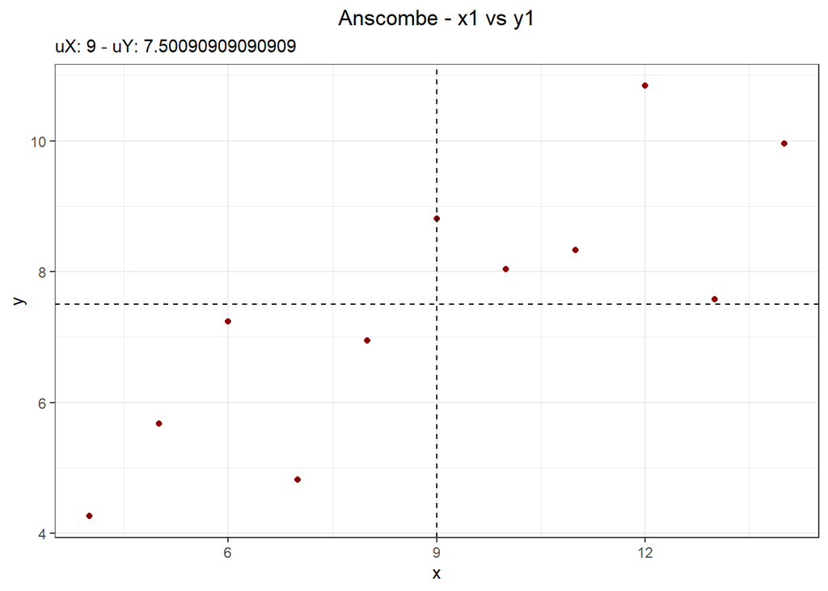

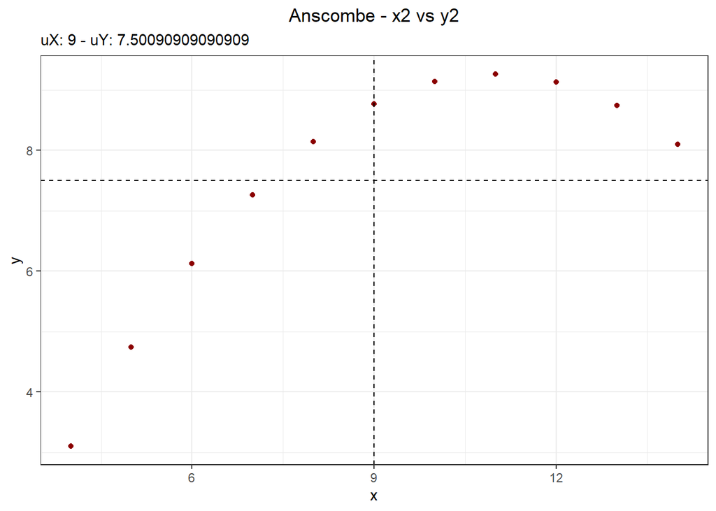

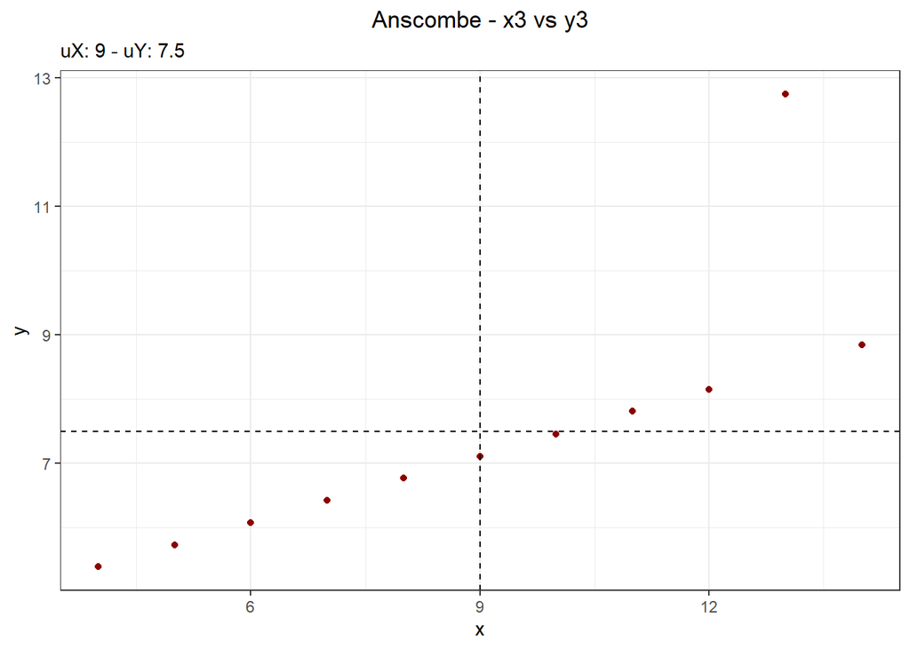

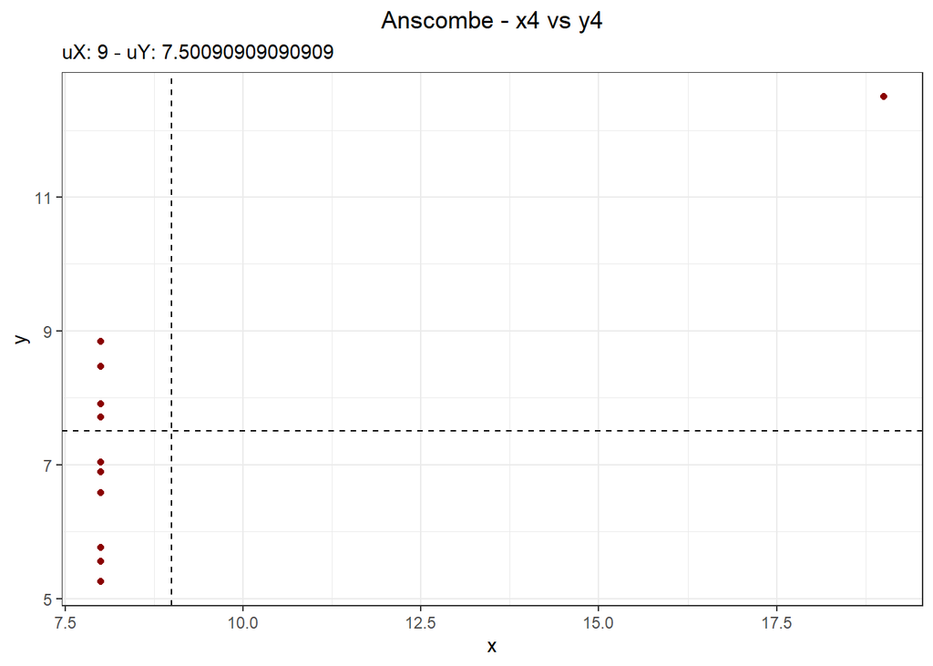

```r
#Tengo que hacerlo para cada par de variables

#Creo un df para almacenar las medias para el punto b
df_mean <- data.frame()
df_sd <- data.frame()
df_cor <- data.frame()

for ( i in 1:4 ) {
  df <- data.frame( x = anscombe[,i], y = anscombe[,i+4] )
  names(df) <- c("x","y")

  #Calculo la media de X
  uX <- mean(df$x)
  #Calculo la media de Y
  uY <- mean(df$y)
  #Almaceno las medias
  df_mean <- rbind(df_mean, data.frame(i, uX, uY))

  title <- paste0("Anscombe - ", "x",i, " vs ", "y",i)
  subtitle <- paste0("uX: ", uX, " - uY: ", uY)
  #Grafico
  plot <- ggplot( data = df, aes( x = x, y = y) ) +
    geom_point( colour = "red4" ) +
    ggtitle( title, subtitle = subtitle ) +
    theme_bw() +
    theme( plot.title = element_text( hjust = 0.5 ) ) +
    geom_quadrant_lines(xintercept = uX , yintercept = uY )

  print(plot)

  #Calculo sd de X
  sdX <- sd(df$x)
  #Calculo sd de Y
  sdY <- sd(df$y)
  #Almaceno los sd
  df_sd <- rbind(df_sd, data.frame(i, sdX, sdY))

  #Calculo de correlacion de cada par
  df_cor <- rbind(df_cor, data.frame(i, cor(df$x,df$y)))

  #Borro las variables creadas temporalmente
  rm(df,uX,uY, sdX, sdY, i, title, subtitle, plot)
}
```

### b) Valores medios

```r
df_mean
```

```
##   i uX       uY
## 1 1  9 7.500909
## 2 2  9 7.500909
## 3 3  9 7.500000
## 4 4  9 7.500909
```

### c) Valores de la dispresión

```r
df_sd
```

```
##   i      sdX      sdY
## 1 1 3.316625 2.031568
## 2 2 3.316625 2.031657
## 3 3 3.316625 2.030424
## 4 4 3.316625 2.030579
```

### d) Coeficiente muestral de correlación lineal

```r
df_cor
```

```
##   i cor.df.x..df.y.
## 1 1       0.8164205
## 2 2       0.8162365
## 3 3       0.8162867
## 4 4       0.8165214
```

### e) Observar, comentar y concluir

Los cuartetos de Anscombe se utilizaron para resaltar la importancia de visualizar los datos y no depender únicamente de medidas resumidas. Destacan la idea de que los valores atípicos y las formas de distribución pueden no ser detectados mediante estadísticas descriptivas básicas. Anscombe argumentaba que los estadísticos deben ser cautelosos y considerar siempre la visualización de los datos antes de realizar cualquier análisis o toma de decisiones basada en ellos. Estos cuartetos son un recordatorio de que la exploración gráfica de los datos es esencial para comprender su estructura y evitar sacar conclusiones erróneas basadas únicamente en medidas numéricas.

## Ejercicio 1.3

### Dataset

```r
icm <- read_excel("./datasets/peso_edad_colest.xlsx")
```

### a) Diagramas dispersión

#### Colesterol en función de la edad

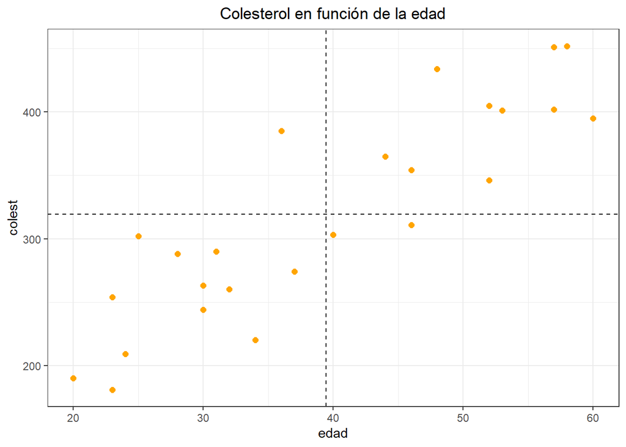

```r
ggplot( data = icm, aes( x = edad, y = colest ) ) +
  geom_point( colour = "orange", size = 2) +
  ggtitle( "Colesterol en función de la edad" ) +
  theme_bw() +
  theme( plot.title = element_text( hjust = 0.5 ) ) +
  geom_quadrant_lines(xintercept = mean(icm$edad) , yintercept = mean(icm$colest) )
```

#### Colesteril en función del peso

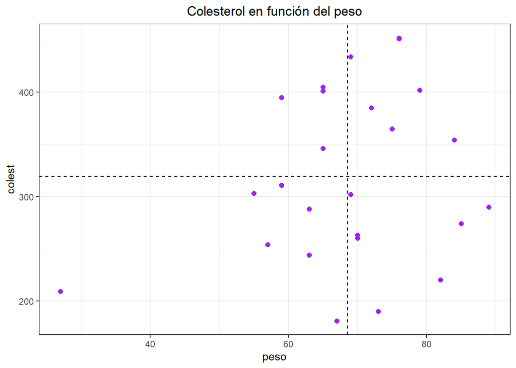

```r
ggplot( data = icm, aes( x = peso, y = colest ) ) +
  geom_point( colour = "purple", size = 2) +
  ggtitle( "Colesterol en función del peso" ) +
  theme_bw() +
  theme( plot.title = element_text( hjust = 0.5 ) ) +
  geom_quadrant_lines(xintercept = mean(icm$peso) , yintercept = mean(icm$colest) )
```

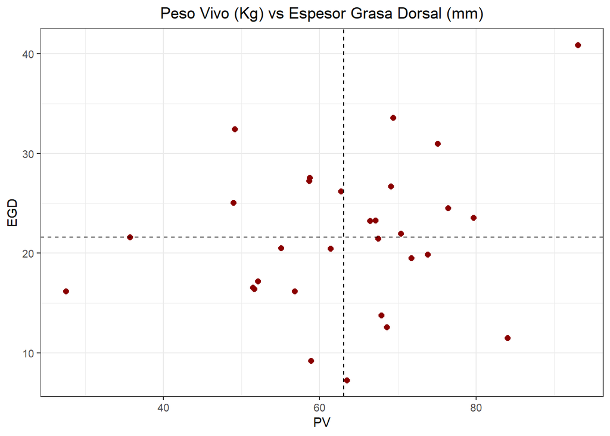

```r
ggplot( data = g_cerdos, aes( x = PV, y = EGD ) ) +
  geom_point( colour = "red4", size = 2) +
  ggtitle( "Peso Vivo (Kg) vs Espesor Grasa Dorsal (mm)" ) +
  theme_bw() +
  theme( plot.title = element_text( hjust = 0.5 ) ) +
  geom_quadrant_lines(xintercept = u_PV , yintercept = u_EGD )
```

### b) Coefiecientes modelo lineal

```r
# Modelo lineal para el colesterol en función de la edad
icm_lm <- lm(colest ~ edad, data = icm)
summary(icm_lm)
```

```
##
## Call:
## lm(formula = colest ~ edad, data = icm)
##
## Residuals:
##     Min      1Q  Median      3Q     Max
## -68.311 -22.602  -2.627  27.589  85.348
##
## Coefficients:
##             Estimate Std. Error t value Pr(>|t|)
## (Intercept)  95.5020    26.2545   3.638  0.00138 **
## edad          5.6708     0.6345   8.937 6.09e-09 ***
## ---
## Signif. codes:  0 '***' 0.001 '**' 0.01 '*' 0.05 '.' 0.1 ' ' 1
##
## Residual standard error: 39.69 on 23 degrees of freedom
## Multiple R-squared:  0.7764, Adjusted R-squared:  0.7667
## F-statistic: 79.87 on 1 and 23 DF,  p-value: 6.094e-09
```

### c) Intervalos de confianza

```r
intervalos_confianza <- confint(icm_lm)
print(intervalos_confianza)
```

```
##                 2.5 %     97.5 %
## (Intercept) 41.190390 149.813618
## edad         4.358216   6.983467
```

```r
#Test de Wald
library(aod)

wald.test(Sigma = vcov(icm_lm), b = coef(icm_lm), Terms = 1)
```

```
## Wald test:
## ----------
##
## Chi-squared test:
## X2 = 13.2, df = 1, P(> X2) = 0.00028
```

### d) Predicciones

```r
nuevos_datos <- data.frame(edad=c(25,48,80))
predicciones <- predict(object = icm_lm,
                        newdata = data.frame(nuevos_datos))
predicciones
```

```
##        1        2        3
## 237.2730 367.7024 549.1693
```

```r
min(icm$colest)
```

```
## [1] 181
```

```r
max(icm$colest)
```

```
## [1] 452
```

```r
int_conf <- predict(object = icm_lm,
                    newdata= nuevos_datos,
                    interval = "confidence",
                    level = 0.95)
int_conf
```

```
##        fit      lwr      upr
## 1 237.2730 212.1954 262.3507
## 2 367.7024 347.8058 387.5990
## 3 549.1693 493.4546 604.8841
```

Se puede estimar el valor de E(Y) para x = 80 años aunque la predicción dado los datos de función de regresión, la predicción no será confiable ya que no es un valor de colesterol compatible con los valores humanos posibles.

Puedo graficar esos puntos para visualizarlos sobre el gráfico original.

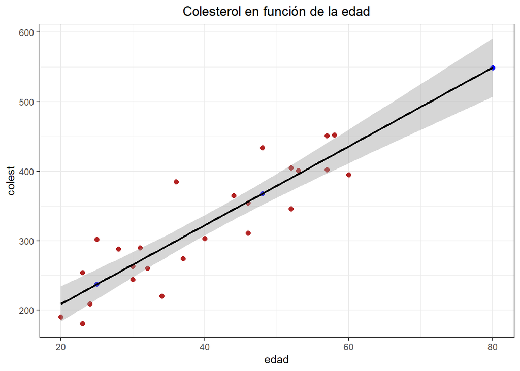

```r
icm_2 <- rbind(icm, c(0,25,237.2730))
icm_2 <- rbind(icm_2, c(0,48,367.7024))
icm_2 <- rbind(icm_2, c(0,80,549.1693))

ggplot(data = icm_2,
       mapping = aes(x = edad, y = colest)) +
  geom_point(color = "firebrick", size = 2) +
  labs( title = "Colesterol en función de la edad" ) +
  geom_point(data = nuevos_datos,
             aes(y = predicciones),
             color = "blue", size = 2) +
  geom_smooth(method = "lm",
              se = TRUE,
              level=0.95,
              color = "black") +
  theme_bw() +
  theme( plot.title = element_text(hjust = 0.5) )
```

### e) Normalidad de residuos

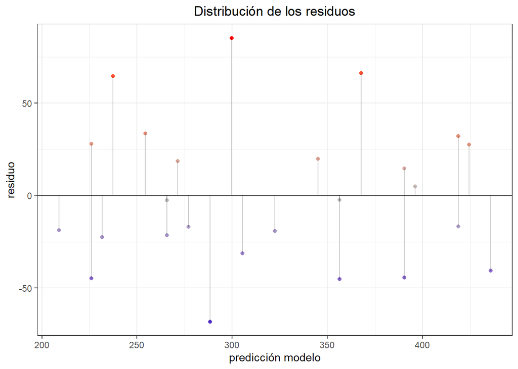

```r
#Analizamos si los residuos son normales
icm2 <- icm
icm2$prediccion <- icm_lm$fitted.values
icm2$residuos <- icm_lm$residuals

ggplot(data = icm2, aes(x = prediccion, y = residuos)) +
  geom_point(aes(color = residuos)) +
  scale_color_gradient2(low = "blue3",
                        mid = "grey",
                        high = "red") +
  geom_hline(yintercept = 0) +
  geom_segment(aes(xend = prediccion,
                   yend = 0),
                  alpha = 0.2) +
  labs(title = "Distribución de los residuos",
       x = "predicción modelo",
       y = "residuo") +
  theme_bw() +
  theme(plot.title = element_text(hjust = 0.5),
        legend.position = "none")
```

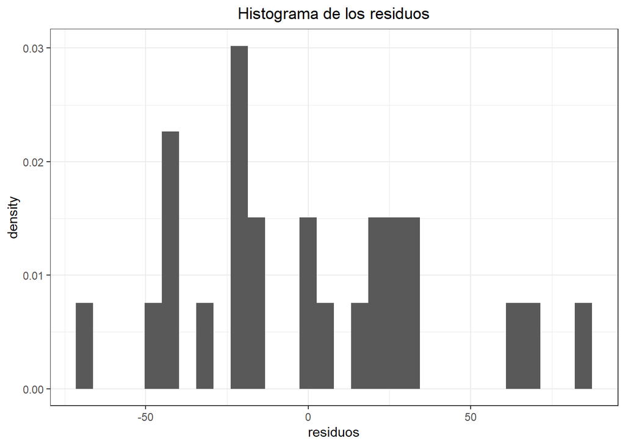

```r
ggplot(data = icm2,
       aes(x = residuos)) +
  geom_histogram(aes(y = ..density..)) +
  labs(title = "Histograma de los residuos") +
  theme_bw() +
  theme(plot.title = element_text(hjust = 0.5))
```

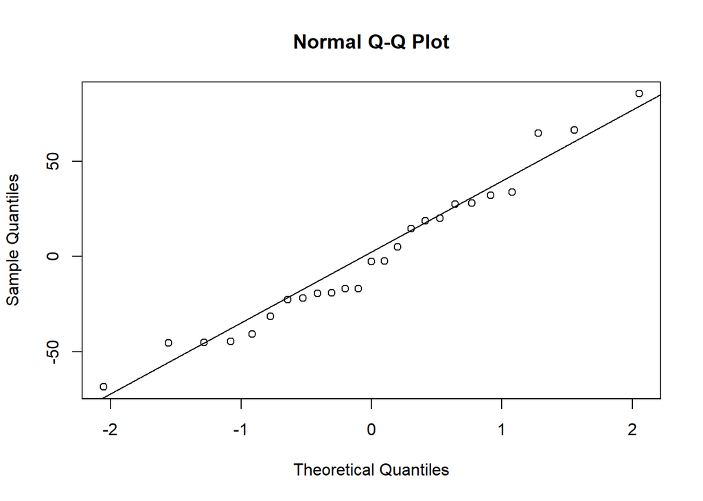

```r
qqnorm(icm_lm$residuals)
qqline(icm_lm$residuals)
```

```r
shapiro.test(icm_lm$residuals)
```

```
##
##  Shapiro-Wilk normality test
##
## data:  icm_lm$residuals
## W = 0.96478, p-value = 0.5175
```

Analizamos si los residuos tienen varianza constante.

```r
#Test de Breush-Pagan
library(lmtest)
bptest(icm_lm)
```

```
##
##  studentized Breusch-Pagan test
##
## data:  icm_lm
## BP = 0.15821, df = 1, p-value = 0.6908
```

Concluimos que no se rechaza homocedasticidad

```r
#Test de Durbin-Watson
library(car)
dwt(icm_lm)
```

```
##  lag Autocorrelation D-W Statistic p-value
##    1       0.1019283      1.783079   0.618
##  Alternative hypothesis: rho != 0
```

## Ejercicio 1.4

### Dataset

```r
energia <- read_excel("./datasets/energia.xlsx")
```

### a) Diagrama de dispersión

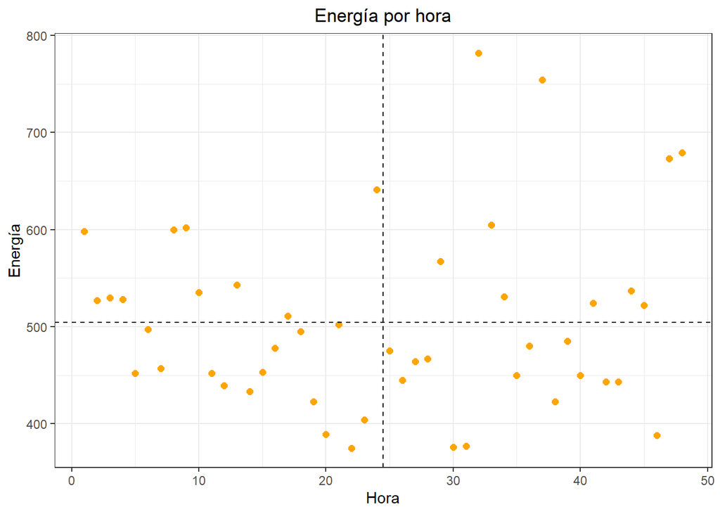

```r
ggplot( data = energia, aes( x = Hora, y = Energía ) ) +
  geom_point( colour = "orange", size = 2) +
  ggtitle( "Energía por hora" ) +
  theme_bw() +
  theme( plot.title = element_text( hjust = 0.5 ) ) +
  geom_quadrant_lines(xintercept = mean(energia$Hora) , yintercept = mean(energia$Energía) )
```

### b)

### c)

### d)

## Ejercicio 1.5

### Dataset

```r
inmo <- read.csv2("./datasets/inmobiliaria.csv", dec = ".")
```

### a)

### b)

### c)

### d)

### e)

## Ejercicio 1.6

### Dataset

```r
estudio <- read.csv2("./datasets/estudio.csv", dec = ".")
```

### a)

### b)

### c)

### d)

### e)